# Epidemic Project

## Introduction

Today we will be looking at a model for the spread of disease at a cellular level. In a scenario like this, there are a few key terms that should be known and understood.

First, we need to know the states that a cell can be in. These consist of:

- **Healthy** - a cell in this state is healthy and has not been infected by the disease
- **Infected** - a cell in this state has been infected by the disease and is sick
- **Recovered** - a cell in this state has ben infected by the disease but has since recovered

It is important to note that in the model we will be using, a cell in the recovered state can not get infected by that disease again.

Each disease has different characteristics, which causes their infection and recovery rates to vary. This means that in our model, we will need to allow any user of this algorithm to input their desired values for these rates. Aside from that, the rest can be explained along the way, so let's get to it!

## Generating a Starting Population of Cells

To begin, we will create a function that gives us a starting state. In this state, we would like to have cells in two states. Either already infected, or healthy. The function we create will need to allow for a different percentage of infected cells at the start, so this will need to be an input. For this report, we will be generating random starting states, meaning that the cells which are infected will be randomly dispersed throughout the distribution of cells. One final thing to mention is that cells which are healthy will be represented with a $0$, the cells that are sick will be represented with a $1$, and the cells which have recovered will be represented with a $2$.

```python
import numpy as np                          # numPy allows us to add randomness to the
                                            # state, as well as put the data for each
                                            # cell into an array
```

```python
def generateRandStart(m,n, perInf):
    """
         m: number of cells in a row

         n: number of cells in a column

    perInf: percentage of cells infected
    """

    vals = np.random.rand(m,n)                      # this line creates an array of the
                                                    # desired size with random numbers
                                                    # throughout

    initial = np.zeros((m,n), dtype=int)            # another array of desired size with
                                                    # integer entries

    initial[vals < perInf] = 1                      # sets desired percentage of cells
                                                    # to infected

    return initial
```

The function above will give us our starting state, which is randomized each time the code is run. This will be used throughout the report to generate random initial populations.

## Determining the Probability that a Cell becomes Sick

Next, let's create a function that incorporates the idea of an infection rate. For this report we will say that if a cell is healthy at one state, the probability that it gets sick at the next state is: $1-(1-p_i)^k$, where $p_i$ is represents the likelihood for a sick cell to infect a healthy cell, and $k$ is the number of sick cells neighboring the cell in question. This formula can be represented in python using the following code:

```python
def probGetsSick(infP, k):
    """
    infP: probability that a cell becomes
           infected

       k: amount of infected neighbors
    """
    return 1 - (1 - infP)**k            # the mathematical formula in python code
```

Note that this function will tell us how likely it is for a cell that we are curious about to get infected. We will choose different values for $p_i$ to see how it affects the population as a whole. The number of infected neighbors, $k$, will need to be determined in order to use this function, which we will see how to do in the following section.

## Count the Number of Infected Neighbors

As we saw in the previous section, we have a function that tells us what the likelihood that a healthy cell gets sick is, but it depends on the number of infected neighbors that the cell has. As we saw in our section regarding generating random starting states, the states will be held in a numPy array. In order to determine the number of infected neighbors we will have, we need to the slice of this array that surrounds the cell in question, and sum the number of infected cells in it.

```python
def countInfectedNeighbors(state,i,j):
    """
    state: the current state for the cells
           in the grid

        i: row index for the cell in question

        j: column index for the cell in question
    """
    grid = np.roll(state,(1-i,1-j),axis=(0,1))[:3,:3]   # grab the slice which will be
                                                        # used to find the number of
                                                        # infected neighbors

    if (state[i,j] == 1):

        return grid[grid==1].sum() - state[i,j]         # number of infected neighbors
                                                        # ignoring the cell in question
    else:

        return grid[grid==1].sum() - state[i,j]         # number of infected neighbors
```

Note that in this report we will be using `np.roll()`, which allows us to wrap the array around, as if it's a globe, so that entries at the upper and lower edge touch, and entries in the left and right most columns touch. This means we don't have to worry about edge cases, which would be a problem if we just took the slice for cell $(i,j)$ as $[i-1:i+2,j-1:j+2]$ because edge cells don't have neighbors surrounding them from all sides.

## Updating the Spread of the Disease

We now have everything we need in order to create the model. The function we create to implement the spread of disease will use all functions above as well as some additional information in order to update the state from one step to the next. The recovery rate will now be used in this function as well as the infection rate. If a cell is sick, it has a certain probability that it recovers by the next time step. This will be implemented in our function through the use of an input `recP` which will be used along with a random number generator to determine if the cell recovered.

```python
def updateSpread(state, infP, recP):
    """
    state: the current state for the cells
           in the grid.

     infP: probability that a cell becomes
           infected

     recP: probability that an infected
           cell recovers
    """

    newState = state.copy()                             # gets an identical copy of
                                                        # the state

    for i, row in enumerate(newState):                  # loops through the rows
        for j, val in enumerate(row):                   # loops through each value
                                                        # in the rows

            if (val == 0):                              # cell is healthy

                # gets the number of infected neighbors
                infNeigh = countInfectedNeighbors(state,
                                                  i, j)

                # gets the probability that the cell gets sick at the next
                # time step
                probSick = probGetsSick(infP, infNeigh)

                # random number between 0 and 1
                randChance = np.random.rand()

                # random number is less than or equal to the probability the
                # cell gets sick
                if (probSick >= randChance):

                    # set that cell's value to 1, indicating that it is now sick
                    newState[i,j] = 1

            # the cell is sick
            elif (val == 1):

                # random number between 0 and 1
                randChance = np.random.rand()

                # random number is less than or equal to the probability the
                # cell gets recovers
                if (recP >= randChance):

                    # set that cell's value to 1, indicating that it is not sick
                    # anymore
                    newState[i,j] = 2

            # the cell has already recovered
            else:

                # do nothing
                continue

    return newState
```

### Disease Spread Example

Below is an example using all of the functions we have created so far. The output of the code is a figure with two subplots, the one on the left being the starting state, and the one on the left being the new state at the next time step.

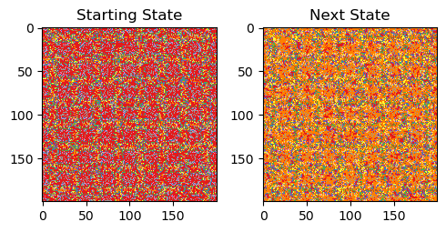

```python
import matplotlib.pyplot as plt             # matplotlib.pyplot allows us to plot arrays
                                            # that represent the state of the population
                                            # of cells

# generates a random starting state
state = generateRandStart(200,200,0.3)

# creates figure that the subplot will be placed in
plt.figure(figsize=(5,10))

# creates a subplot, and grabs the first section of it
plt.subplot(1,2,1)
plt.imshow(state, cmap="Set1")            # plots the array into colors, each color
                                          # representing a different state
plt.title("Starting State")               # gives the plot a title

# grabs the second section of the subplot
plt.subplot(1,2,2)
infP = 0.5                                # sets our infection probability to 0.5
recP = 0.5                                # sets our recovery probability to 0.5
newState = updateSpread(state,
                        infP,             # gets the new state based on the state prior
                        recP)
plt.imshow(newState, cmap="Set1")         # plots the array into colors, each color
                                          # representing a different state
plt.title("Next State")                   # gives the plot a title

plt.tight_layout()                        # fits the figure to make it look nicer
```

As we can see from this example, the state of a population of cells can change drastically from one time step to the next. We want to find a steady state for any given set of parameters, which means we will need to be able to update the spread of the disease many times, which is where we will head next.

## Finding a Steady State

The goal in finding a steady state for a given population of cells and the parameters inputted is to be able to determine in different situations, how will the cells as a whole be affected by a disease over the long run. To do this, we will need to be able to run the code above, which gets the next state multiple times. The function below implements this functionality, so that we don't have to do it manually, or set up our own loop.

```python
def nUpdates(n, state, infP, recP):
    """
        n: number of updates to the spread

    state: the current state for the cells
           in the grid.

     infP: probability that a cell becomes
           infected

     recP: probability that an infected
           cell recovers
    """

    currState = state.copy()                    # gets a copy of the current state

    for i in range(n):                          # loop with (number of updates)
                                                # iterations

        currState = updateSpread(currState,     # updates the current state to the state
                                 infP, recP)    # at the next time step

    return currState
```

Now that we have this function we will be able to analyze the model to determine how diseases with the characteristics explained throughout the report affect populations of cells.

### How Infection Probability Affects Steady State

Let's first look at how changing the infection probability changes the steady state of our population of cells. The code below runs the same starting state through $100$ updates of the spread, with the only difference in each instance being the probability of infection. The output is a figure with four subplots, one for each of the scenarios.

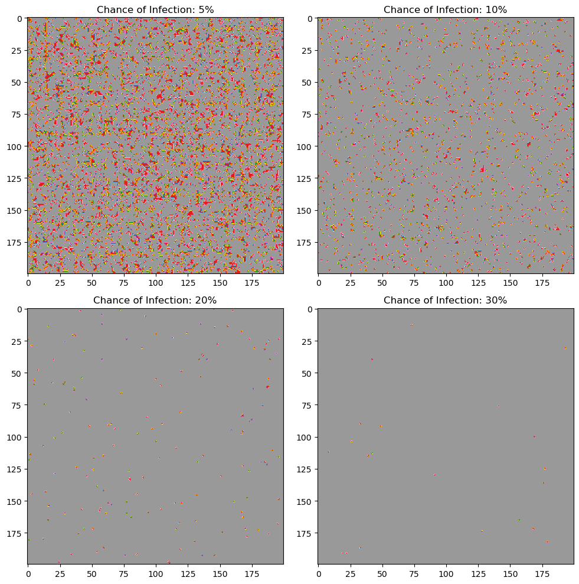

```python
# creates the figure
plt.figure(figsize=(10,10))

# generates random starting state
starting_state = generateRandStart(200,200,0.5)

# creates subplot where the infection probability is 5%
plt.subplot(2,2,1)
infP=0.05
recP=0.3
ss = nUpdates(100, starting_state, infP, recP)
plt.imshow(ss, cmap="Set1")
plt.title("Chance of Infection: 5%")

# creates subplot where the infection probability is 10%
plt.subplot(2,2,2)
infP=0.1
recP=0.3
ss = nUpdates(100, starting_state, infP, recP)
plt.imshow(ss, cmap="Set1")
plt.title("Chance of Infection: 10%")

# creates subplot where the infection probability is 20%
plt.subplot(2,2,3)
infP=0.2
recP=0.3
ss = nUpdates(100, starting_state, infP, recP)
plt.imshow(ss, cmap="Set1")
plt.title("Chance of Infection: 20%")

# creates subplot where the infection probability is 30%
plt.subplot(2,2,4)
infP=0.3
recP=0.3
ss = nUpdates(100, starting_state, infP, recP)
plt.imshow(ss, cmap="Set1")
plt.title("Chance of Infection: 30%")

plt.tight_layout()
```

The figure above shows the affect that changing the infection probability has on the population of cells. In the top left subplot, there is a $5\%$ chance that an infected cell will cause a healthy cell to get sick. In this scenario, we see a steady state where maybe around half of the cells are recovered from the disease (represented in gray), while there are also many cells that have never gotten infected. This is not the exact steady state, as some of the cells are sick. If we did more and more iterations we would likely see that the steady state has only healthy cells and recovered cells. In the top right subplot, we see that much more of the cells are in the recovered state, which makes sense as the chance of infection doubled to $10\%$, meaning that each cell was twice as likely to become infected from any single infected cell. There are still a large number of cells that did not ever get the disease. In the bottom left subplot, we again doubled the probability of infection to $20\%$, and we see that even more of the cells are in the recovered state. Looking at the bottom right subplot, we see that when increase the infection probability to $30\%$ and beyond, most if not all of the cells will become infected at some point, and then eventually recover.

### How Recovery Rate Affects Steady State

Let's now look at how changing the recovery rate affects the steady state for a population of cells. As was done before, we will again run the same starting state through $100$ updates to the spread four times, where each of the four times we slightly tweak the recovery rate. For this study we will start with all of the cells being sick, to see the affect of the recovery rate

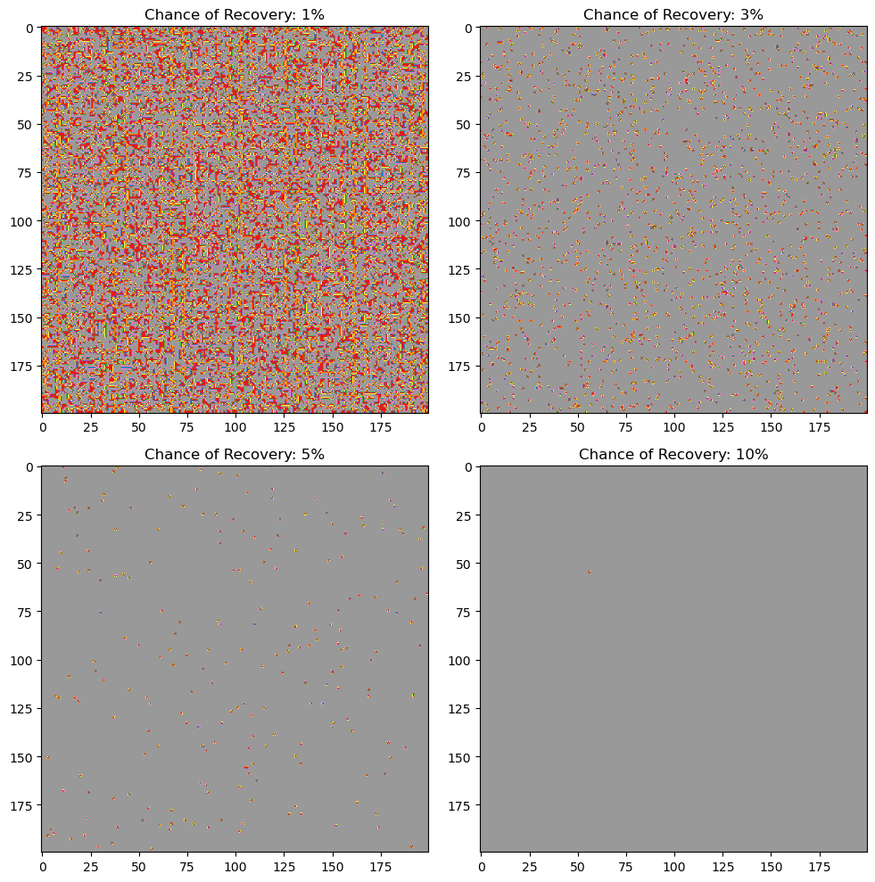

```python
# creates the figure
plt.figure(figsize=(10,10))

# generates random starting state
starting_state = generateRandStart(200,200,1)

# creates subplot where the recovery probability is 5%
plt.subplot(2,2,1)
infP=0.3
recP=0.01
ss = nUpdates(100, starting_state, infP, recP)
plt.imshow(ss, cmap="Set1")
plt.title("Chance of Recovery: 1%")

# creates subplot where the recovery probability is 10%
plt.subplot(2,2,2)
infP=0.3
recP=0.03
ss = nUpdates(100, starting_state, infP, recP)
plt.imshow(ss, cmap="Set1")
plt.title("Chance of Recovery: 3%")

# creates subplot where the recovery probability is 20%
plt.subplot(2,2,3)
infP=0.3
recP=0.05
ss = nUpdates(100, starting_state, infP, recP)
plt.imshow(ss, cmap="Set1")
plt.title("Chance of Recovery: 5%")

# creates subplot where the recovery probability is 30%
plt.subplot(2,2,4)
infP=0.3
recP=0.1
ss = nUpdates(100, starting_state, infP, recP)
plt.imshow(ss, cmap="Set1")
plt.title("Chance of Recovery: 10%")

plt.tight_layout()
```

## How a Vaccine can Change Results

In this section we will examine what role a vaccine plays in the spread of a disease. Due to the nature of how we built our algorithm in the previous sections, there is only one function that needs to be modified, that being the population of cells generator. Instead of giving the cells values of either $0$ or $1$, depending on whether that cell has been designated sick or not, we will also have some vaccinated cells, which we will represent with the value: $-1$. The function below implements our desired functionality, where we input the percentage of cells we would like to be infected and the percentage of cells we would like to be vaccinated, and we get out a starting state with those parameters met.

```python
def vaccRandStart(m, n, perInf, perVac):
    """
         m: number of cells in a row

         n: number of cells in a column

    perInf: percentage of cells infected

    perVac: percentage of cells vaccinated
    """

    vals = np.random.rand(m,n)                  # array of desired size with random
                                                # values everywhere


    initial = np.zeros((m,n), dtype=int)        # array of desired size with all 0's


    initial[vals<perVac] = -1                   # sets desired amount of cells to
                                                # vaccinated

    initial[vals>1-perInf] = 1                  # sets desired amount of cells to sick


    return initial
```

Note that the spread function made prior doesn't need to be modified, because the way we coded it cells that are not $0$ or $1$ will be skipped over, so we don't need to tell the function what to do if the value of the array at that index is $-1$.

### Affects of a Vaccine

We can now look at how a vaccine affects the population of cells. Below we again have four different scenarios. The only difference between each of them is the percentage of cells in the starting population who are vaccinated.

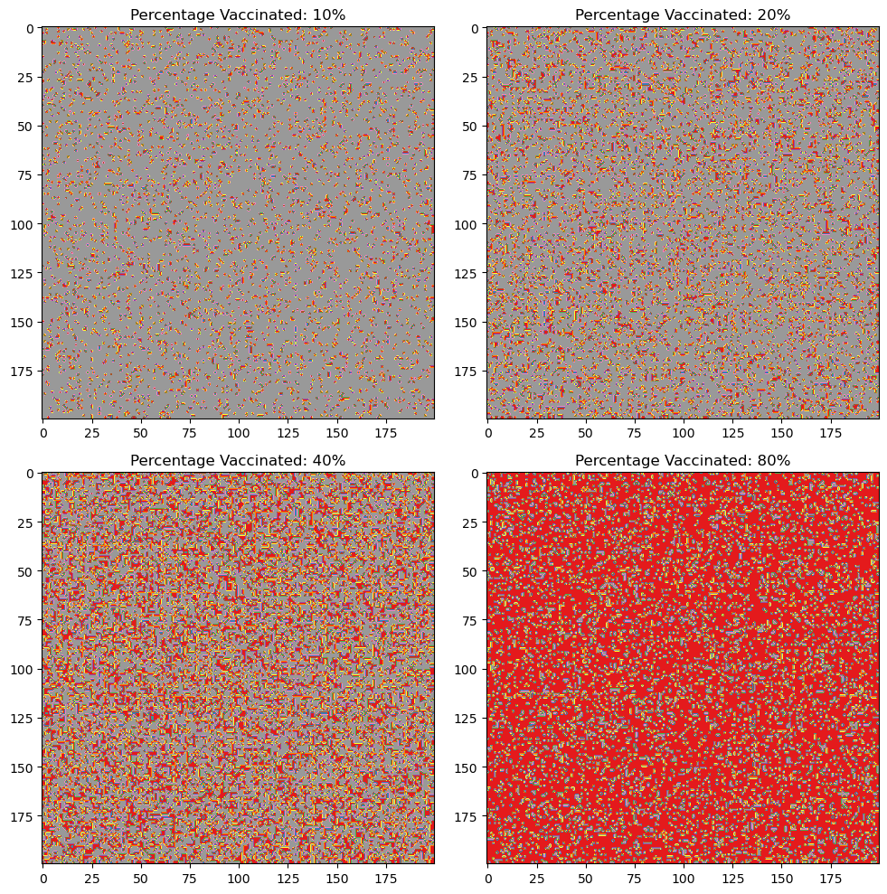

```python
# creates figure
plt.figure(figsize=(10,10))

# sets the infection and recovery probabilities, as well as the percentage of
# infected individuals in the starting state
perInf = 0.2
infP = 0.35
recP = 0.05

# creates subplot where the percentage of cells vaccinated is 10%
plt.subplot(2,2,1)
perVac = 0.1
starting_state = vaccRandStart(200,200,perInf,perVac)
ss = nUpdates(100, starting_state, infP, recP)
plt.imshow(ss, cmap="Set1")
plt.title("Percentage Vaccinated: 10%")

# creates subplot where the percentage of cells vaccinated is 20%
plt.subplot(2,2,2)
perVac = 0.2
starting_state = vaccRandStart(200,200,perInf,perVac)
ss = nUpdates(100, starting_state, infP, recP)
plt.imshow(ss, cmap="Set1")
plt.title("Percentage Vaccinated: 20%")

# creates subplot where the percentage of cells vaccinated is 40%
plt.subplot(2,2,3)
perVac = 0.4
starting_state = vaccRandStart(200,200,perInf,perVac)
ss = nUpdates(100, starting_state, infP, recP)
plt.imshow(ss, cmap="Set1")
plt.title("Percentage Vaccinated: 40%")

# creates subplot where the percentage of cells vaccinated is 80%
plt.subplot(2,2,4)
perVac = 0.8
starting_state = vaccRandStart(200,200,perInf,perVac)
ss = nUpdates(100, starting_state, infP, recP)
plt.imshow(ss, cmap="Set1")
plt.title("Percentage Vaccinated: 80%")

plt.tight_layout()
```

The figure above shows the results for different percentages of cells being vaccinated. In the top left subplot, $10\%$ of the population is vaccinated, and we see that many of cells got infected, and are now in the recovery phase. As the percentage of vaccinated cells increases, we see that more and more of the population never gets the disease. This makes sense as the vaccinated cells in this scenario can not get the disease. Thus, vaccines which render a disease powerless are an affective way of combatting disease.

## Animation

Below is an animation for some specified values of starting state, infection probability, and recovery rate. Feel free to change these to see their effects at each time step.

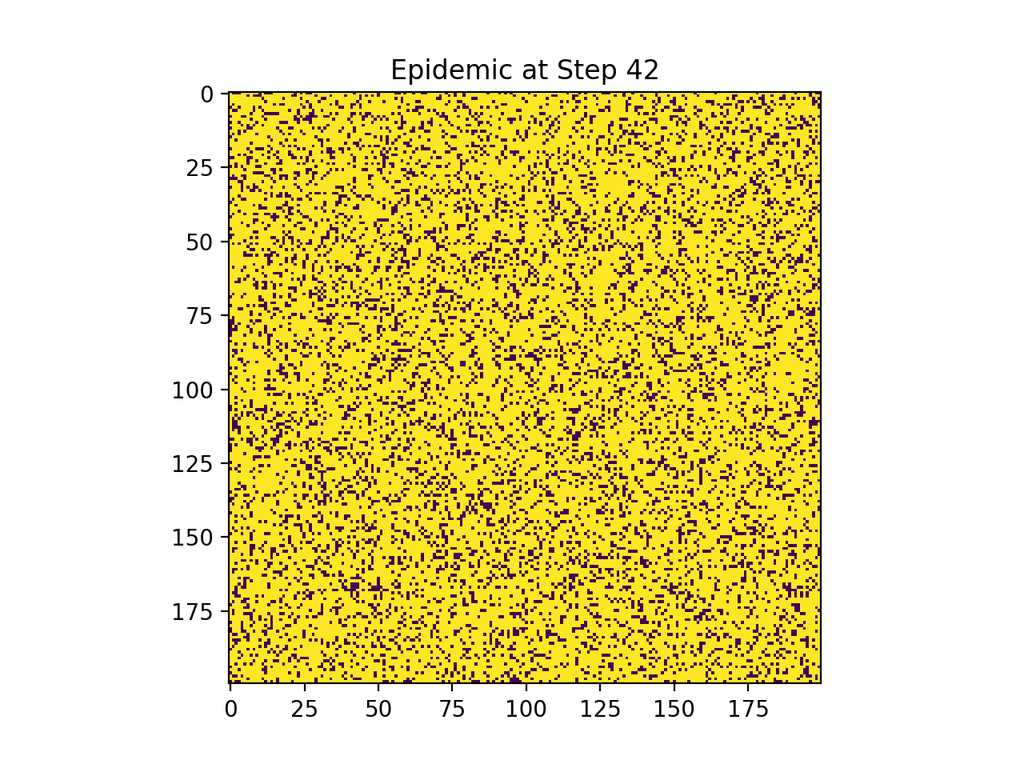

```python
%matplotlib notebook

import numpy as np
import matplotlib.pyplot as plt
from matplotlib.animation import FuncAnimation

x = vaccRandStart(200,200,0.3,0.2)

infP = 0.35
recP = 0.05

fig = plt.figure()
im = plt.imshow(x,vmin=0,vmax=1)


def animate(i):
    global x
    x=updateSpread(x, infP, recP)
    plt.title("Epidemic at Step {:}".format(i))
    im.set_data(x)
    return im

anim = FuncAnimation(fig,animate)
plt.show()
```

## Conclusion

In this report we learned that increasing the probability of infection will increase the number of cells that get infected. This means that as the probability of infection approaches one, the steady state of that population will be filled with all cells in the recovered state, assuming that the recovery rate is non-zero. The more interesting findings in this report come from the effects of changing the recovery rate and adding a vaccine. As the recovery rate is increased, cells are able to recover quicker, which means less cells get infected. The result is that once the population reaches a steady state, some of the cells that may have gotten infected before didn't. As the recovery rate approaches one, the number of cells which get infected decreases, assuming that all cells don't start infected. Finally, we learned that a working vaccine can greatly diminish a disease's potential. We saw that, for effective vaccines, the more cells in the population which are vaccinated, the less cells that got infected, which makes sense because vaccinated cells in this scenario can not be infected. As the number of vaccinated cells approaches its maximum, the number of infected cells approaches 0.